# Deep Learning Lab Session

# First Lab Session - 3 Hours

# Artificial Neural Networks for Handwritten Digits Recognition

**Student 1:** Albane Bonnaud **Student 2:** Kim-Anh-Nhi Nguyen **Group name:** deeplearn38

The aim of this session is to practice with Artificial Neural Networks. Answers and experiments should be made by groups of two students. Each group should fill and run appropriate notebook cells.

To generate your final report and upload it on the submission website http://bigfoot-m1.eurecom.fr/teachingsub/login (using your deeplearnXX/password). Do not forget to run all your cells before generating your final report and do not forget to include the names of all participants in the group. The lab session should be completed ans submitted by April 13th 2018 (23:59:59 CET).

# Introduction

During this lab session, you will implement, train and test a Neural Network for the Handwritten Digits Recognition problem [[1]](http://yann.lecun.com/exdb/mnist/) with different settings of hyperparameters. You will use the MNIST dataset which was constructed from scanned documents available from the National Institute of Standards and Technology (NIST). Images of digits were taken from a variety of scanned documents, normalized in size and centered.

This assignment includes a written part of programms to help you understand how to build and train your neural net and then to test your code and get results.

1. NeuralNetwork.py
2. transfer_functions.py
3. utils.py

Functions defined inside the python files mentionned above can be imported using the python command "from filename import function".

You will use the following libraries:

1. [numpy](http://cs231n.github.io/python-numpy-tutorial/) : for creating arrays and using methods to manipulate arrays;
2. [matplotlib](http://matplotlib.org/) : for making plots.

Before starting the lab, please launch the cell below. After that, you may not need to do any imports during the lab.

```python
# All imports
from NeuralNetwork import NeuralNetwork
from transfer_functions import *
from utils import *
import numpy as np
import matplotlib
```

# Section 1 : Your First Neural Network

**Part 1**: Before designing and writing your code, you will first work on a neural network by hand. Consider the following neural network with two inputs $x=(x_1,x_2)$, one hidden layer and a single output unit $y$. The initial weights are set to random values. Neurons 6 and 7 represent biases. Bias values are equal to 1. You will consider a training sample whose feature vector is $x = (0.8, 0.2)$ and whose label is $y = 0.4$.

Assume that neurons have a sigmoid activation function $f(x)=\frac{1}{(1+e^{-x})}$. The loss function $L$ is a Mean Squared Error (MSE): if $o$ denotes the output of the neural network, then the loss for a given sample $(o, y)$ is $L(o, y) = \left|\left| o - y \right|\right|^2$. In the following, you will assume that if you want to backpropagate the error on a whole batch, you will backpropagate the average error on that batch. More formally, let $((x^{(1)}, y^{(1)}), ..., (x^{(N)}, y^{(N)}))$ be a batch and $o^{(k)}$ the output associated to $x^{(k)}$. Then the total error $\bar{L}$ will be as follows:

$\bar{L} = \frac{1}{N} \sum_{k=1}^{N} L(o^{(k)}, y^{(k)})$.

**Question 1.1.1**: Compute the new values of weights $w_{i,j}$ after a forward pass and a backward pass, and the outputs of the neural network before and after the backward path, when the learning rate is $\lambda$=5. $w_{i,j}$ is the weight of the connexion between neuron $i$ and neuron $j$. Please detail your computations in the cell below and print your answers.

```python
lr = 5.0
x1, x2, x6, x7 = 0.8, 0.2, 1.0, 1.0
w13, w14, w23, w24, w63, w64 = 0.3, -0.5, 0.8, 0.2, 0.2, -0.4
w35, w45, w75 = -0.6, 0.4, 0.5
y = 0.4

x3 = sigmoid(x1*w13 + x2*w23 + x6*w63)
x4 = sigmoid(x1*w14 + x2*w24 + x6*w64)
x5 = sigmoid(x3*w35 + x4*w45 + x7*w75) #to check: output layer a une fonction activation??


print("=== FORWARD PASS 1 ===")
print("Output =", x5)

diff5 = x5 - y #we introduce a intermediate variable

d_u = diff5 * x5 * (1-x5)

d_w35 = d_u * x3
d_w45 = d_u * x4
d_w75 = d_u * x7



d_w13 = (d_u * w35) * x3 * (1-x3) * x1
d_w14 = (d_u * w45) * x4 * (1-x4) * x1
d_w23 = (d_u * w35) * x3 * (1-x3) * x2
d_w24 = (d_u * w45) * x4 * (1-x4) * x2
d_w63 = (d_u * w35) * x3 * (1-x3) * x6
d_w64 = (d_u * w45) * x4 * (1-x4) * x6

w13 -= lr*d_w13
w14 -= lr*d_w14
w23 -= lr*d_w23
w24 -= lr*d_w24
w63 -= lr*d_w63
w64 -= lr*d_w64
w35 -= lr*d_w35
w45 -= lr*d_w45
w75 -= lr*d_w75

print("=== BACKWARD PASS ===")
print("w13 =", w13)
print("w14 =", w14)
print("w23 =", w23)
print("w24 =", w24)
print("w63 =", w63)
print("w64 =", w64)
print("w35 =", w35)
print("w45 =", w45)
print("w75 =", w75)

x3 = sigmoid(x1*w13 + x2*w23 + x6*w63)
x4 = sigmoid(x1*w14 + x2*w24 + x6*w64)
x5 = sigmoid(x3*w35 + x4*w45 + x7*w75)

print("=== FORWARD PASS 2 ===")
print("Output =", x5)
```

```
=== FORWARD PASS 1 ===
Output = 0.5597295991095776
=== BACKWARD PASS ===
w13 = 0.3216132716107736
w14 = -0.5136736550937697
w23 = 0.8054033179026935
w24 = 0.19658158622655758
w63 = 0.22701658951346695
w64 = -0.4170920688672122
w35 = -0.7270733753139802
w45 = 0.3372863608886286
w75 = 0.303187277675964
=== FORWARD PASS 2 ===
Output = 0.48291466025563257
```

COMMENT :

The first output (approximately 0.56) is quite close to the target label $y=0.4 $.

The second output (approximately 0.48) is better, even closer to the target label.

**Part 2**: Neural Network Implementation

Please read all source files carefully and understand the data structures and all functions. You are to complete the missing code. First you should define the neural network (using the NeuralNetwork class, see in the NeuralNetwork.py file) and reinitialise weights. Then you will need to complete the feedforward() and the backpropagate() functions.

**Question 1.2.1**: Implement the feedforward() function.

```python
class NeuralNetwork(NeuralNetwork):
    def feedforward(self, inputs):
        batch_size=len(inputs)
        #INITIALIZE THE FOLLOWING TO ADAPT TO BATCH SIZE
        # initialize arrays for activations
        self.u_hidden = np.zeros((batch_size, self.hidden_layer_size-1))
        self.u_output = np.zeros((batch_size, self.output_layer_size))

        # initialize arrays for outputs
        self.o_input = np.ones((batch_size, self.input_layer_size))
        self.o_hidden = np.ones((batch_size, self.hidden_layer_size))
        self.o_output = np.ones((batch_size, self.output_layer_size))

        # initialize arrays for partial derivatives according to activations
        self.dE_du_hidden = np.zeros((batch_size, self.hidden_layer_size-1))
        self.dE_du_output = np.zeros((batch_size, self.output_layer_size))

        #INITIALIZATION
        self.o_input = np.array(inputs)
        #insert bias
        o_input_b = np.append(self.o_input, np.ones((len(inputs), 1)), axis=1)

        #HIDDEN LAYER
        self.u_hidden = np.dot(o_input_b, self.W_input_to_hidden)
        self.o_hidden = self.transfer_f(self.u_hidden)
        #OUTPUT LAYER
        o_hidden_b = np.append(self.o_hidden, np.ones((len(self.o_hidden), 1)), axis=1)
        self.u_output = np.dot(o_hidden_b,self.W_hidden_to_output)
        self.o_output = self.transfer_f(self.u_output)
        pass
```

**Question 1.2.2**: Test your implementation: create the Neural Network defined in Part 1 and see if the feedforward() function you implemented gives the same results as the ones you found by hand.

```python
# First define your neural network
model = NeuralNetwork(2,2,1)

# Then initialize the weights according to Figure 2
W_input_to_hidden = np.array([[0.3, -0.5], [0.8, 0.2], [0.2, -0.4]])
W_hidden_to_output = np.array([[-0.6], [0.4], [0.5]])
model.weights_init(W_input_to_hidden, W_hidden_to_output)

# Feed test values
test = [[0.8, 0.2]]
model.feedforward(test)

# Print the output
print("Output =", model.o_output[0,0])
```

```
Output = 0.5597295991095776
```

COMMENT :

With the feedforward() function, we obtain the same result as in question 1.1.1. That's to say an output equal to 0.5597295991095776.

Our implementation works well.

**Question 1.2.3**: Implement the backpropagate() function.

```python
class NeuralNetwork(NeuralNetwork):
    def backpropagate(self, targets, learning_rate=5.0):

        batch_size=len(self.o_input)
        N=len(targets)

        #OUTPUT LAYER
        #compute the difference between the network ouput and the desired output
        diff = self.o_output-targets

        #compute the partial derivative of the error with respect to the activation at the output layer
        self.dE_du_output = np.multiply(diff,self.transfer_df(self.u_output))

        o_hidden_with_bias = np.append(self.o_hidden, np.ones((len(self.o_hidden), 1)), axis=1)

        dE_dw_output = np.dot(self.dE_du_output.T, o_hidden_with_bias).T

        #HIDDEN LAYER
        #weightedsum
        weighted_sum = np.dot(self.dE_du_output, self.W_hidden_to_output.T)
        u_hidden_with_bias = np.append(self.u_hidden ,np.ones((len(self.u_hidden), 1)), axis=1)
        self.dE_du_hidden = np.multiply(weighted_sum , self.transfer_df(u_hidden_with_bias))

        #remove the bias
        self.dE_du_hidden = np.delete(self.dE_du_hidden, len(self.dE_du_hidden[0])-1, axis=1)
        o_input_with_bias = np.append(self.o_input ,np.ones((len(self.o_input), 1)), axis=1)
        dE_dw_hidden = np.dot(self.dE_du_hidden.T, o_input_with_bias).T

        #UPDATING
        self.W_hidden_to_output = self.W_hidden_to_output-learning_rate*dE_dw_output/N
        self.W_input_to_hidden = self.W_input_to_hidden-learning_rate*dE_dw_hidden/N

        pass
```

**Question 1.2.4**: Test your implementation: create the Neural Network defined in Part 1 and see if the backpropagate() function you implemented gives the same weight updates as the ones you found by hand. Do another forward pass and see if the new output is the same as the one you obtained in Question 1.1.1.

```python
# First define your neural network
model = NeuralNetwork(2,2,1)
#model = NeuralNetwork(input_layer_size=2, hidden_layer_size=2, output_layer_size=1, transfer_f=sigmoid, transfer_df=dsigmoid)

# Then initialize the weights according to Figure 2
W_input_to_hidden = np.array([[0.3, -0.5], [0.8, 0.2], [0.2, -0.4]])
W_hidden_to_output = np.array([[-0.6], [0.4], [0.5]])
model.weights_init(W_input_to_hidden, W_hidden_to_output)

# Feed test values
test = [[0.8, 0.2]]
model.feedforward(test)

# Backpropagate
targets = [[0.4]]
model.backpropagate(targets)

# Print weights
print("W_input_to_hidden =", model.W_input_to_hidden)
print("W_hidden_to_output =", model.W_hidden_to_output)

# Feed test values again
model.feedforward(test)

# Print the output
print("Output =", model.o_output)
```

```
W_input_to_hidden = [[ 0.32161327 -0.51367366]
 [ 0.80540332  0.19658159]
 [ 0.22701659 -0.41709207]]
W_hidden_to_output = [[-0.72707338]
 [ 0.33728636]
 [ 0.30318728]]
Output = [[0.48291466]]
```

COMMENT :

With the backpropagate() function, we obtain the same result as in question 1.1.1. After a forward pass, a backward pass, and a forward pass again, we reach the same enhanced output of 0.48291466.

We can even check if, for many iterations, the output correctly converges towards 0.4 (see cell below).

```python
model = NeuralNetwork(2,2,1)

W_input_to_hidden = np.array([[0.3, -0.5], [0.8, 0.2], [0.2, -0.4]])
W_hidden_to_output = np.array([[-0.6], [0.4], [0.5]])
model.weights_init(W_input_to_hidden, W_hidden_to_output)
test = [[0.8, 0.2]]
targets = [[0.4]]
for i in range (10):
    model.feedforward(test)
    model.backpropagate(targets)
    model.feedforward(test)
    print("Output =", model.o_output)
```

```
Output = [[0.48291466]]
Output = [[0.44214485]]
Output = [[0.42178459]]
Output = [[0.4114349]]
Output = [[0.40605965]]
Output = [[0.40322848]]
Output = [[0.40172516]]
Output = [[0.40092333]]
Output = [[0.4004946]]
Output = [[0.40026507]]
```

COMMENT :

Our output gradually gets closer to the target 0.4.

Our implementation works well.

Checked your implementations and found that everything was fine? Congratulations! You can move to the next section.

# Section 2: Handwritten Digits Recognition

The MNIST dataset consists of handwritten digit images. It is split into a training set containing 60,000 samples and a test set containing 10,000 samples. In this Lab Session, the official training set of 60,000 images is divided into an actual training set of 50,000 samples a validation set of 10,000 samples. All digit images have been size-normalized and centered in a fixed size image of 28 x 28 pixels. Images are stored in byte form: you will use the NumPy python library to convert data files into NumPy arrays that you will use to train your Neural Networks.

You will first work with a small subset of MNIST (1000 samples), then on a very small subset of MNIST (10 samples), and eventually run a model on the whole one.

The MNIST dataset is available in the Data folder. To get the training, testing and validation data, run the load_data() function.

```python
# Just run that cell ;-)
training_data, validation_data, test_data = load_data()
small_training_data = (training_data[0][:1000], training_data[1][:1000])
small_validation_data = (validation_data[0][:200], validation_data[1][:200])
indices = [1, 3, 5, 7, 2, 0, 13, 15, 17, 4]
vsmall_training_data = ([training_data[0][i] for i in indices], [training_data[1][i] for i in indices])
```

```
Loading MNIST data .....
Done.
```

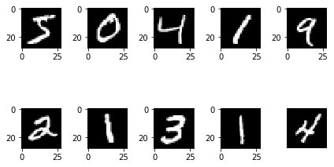

```python
# And you can run that cell if you want to see what the MNIST dataset looks like
ROW = 2
COLUMN = 5
for i in range(ROW * COLUMN):
    # train[i][0] is i-th image data with size 28x28
    image = np.array(training_data[0][i]).reshape(28, 28)
    plt.subplot(ROW, COLUMN, i+1)
    plt.imshow(image, cmap='gray')  # cmap='gray' is for black and white picture.
plt.axis('off')  # do not show axis value
plt.tight_layout()   # automatic padding between subplots
plt.show()
```

**Part 1**: Build a bigger Neural Network

The input layer of the neural network that you will build contains neurons encoding the values of the input pixels. The training data for the network will consist of many 28 by 28 pixel images of scanned handwritten digits. Thus, the input layer contains 784=28×28 units. The second layer of the network is a hidden layer. We set the number of neurons in the hidden layer to 30. The output layer contains 10 neurons.

**Question 2.1.1**: Create the network described above using the NeuralNetwork class.

```python
# Define your neural network
mnist_model = NeuralNetwork(784,30,10)
```

**Question 2.1.2**: Train your Neural Network on the small subset of MNIST (300 iterations) and print the new accuracy on test data. You will use small_validation_data for validation. Try different learning rates (0.1, 1.0, 10.0). You should use the train() function of the NeuralNetwork class to train your network, and the weights_init() function to reinitialize weights between tests. Print the accuracy of each model on test data using the predict() function.

COMMENT : Just to make sure there will be no confusion on the graphs:

The **blue curves** represent the accuracy on the **training set**.

The **orange curves** represent the accuracy on the **validation set**.

```
########### Learning Rate : 0.1   |   Iterations : 300   |   Hidden Neurons : 30 ###########
Training time: 52.2757682800293
```

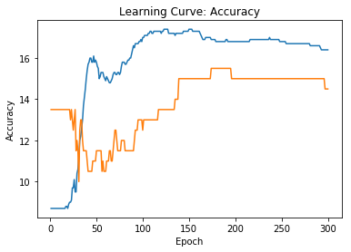

```
########### Learning Rate : 1.0   |   Iterations : 300   |   Hidden Neurons : 30 ###########
Training time: 58.1571683883667
```

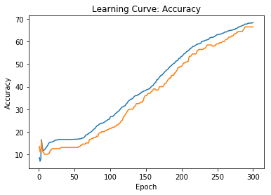

```
########### Learning Rate : 10.0   |   Iterations : 300   |   Hidden Neurons : 30 ###########
Training time: 48.590482234954834
```

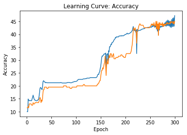

```
4312
```

```python
# Train NN and print accuracy on test data

# Learning rate 0.1

print('\n########### Learning Rate : 0.1   |   Iterations : 300   |   Hidden Neurons : 30 ###########')
mnist_model.train(small_training_data , small_validation_data , iterations=300, learning_rate=0.1, verbose=False)
mnist_model.predict(test_data)
""" predict() evaluates performance by counting how many examples in test_data are correctly evaluated. """
mnist_model.weights_init(wi=None,wo=None)

# Learning rate 1.
print('\n########### Learning Rate : 1.0   |   Iterations : 300   |   Hidden Neurons : 30 ###########')
mnist_model.train(small_training_data , small_validation_data , iterations=300, learning_rate=1.0, verbose=False)
mnist_model.predict(test_data)
mnist_model.weights_init(wi=None,wo=None)


# Learning rate 10.
print('\n########### Learning Rate : 10.0   |   Iterations : 300   |   Hidden Neurons : 30 ###########')
mnist_model.train(small_training_data , small_validation_data , iterations=300, learning_rate=10.0, verbose=False)
mnist_model.predict(test_data)
```

**Question 2.1.3**: Do the same with 15 and 75 hidden neurons.

```
########### Learning Rate : 0.1   |   Iterations : 300   |   Hidden Neurons : 15 ###########
Training time: 56.3658549785614
```

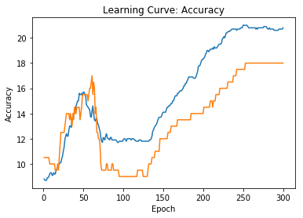

```
########### Learning Rate : 1.0   |   Iterations : 300   |   Hidden Neurons : 15 ###########
Training time: 56.31215143203735
```

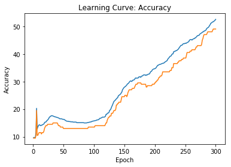

```
########### Learning Rate : 10.0  |   Iterations : 300   |   Hidden Neurons : 15 ###########
Training time: 49.82942771911621
```

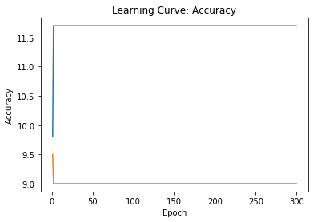

```
########### Learning Rate : 0.1   |   Iterations : 300   |   Hidden Neurons : 75 ###########
Training time: 55.87425494194031
```

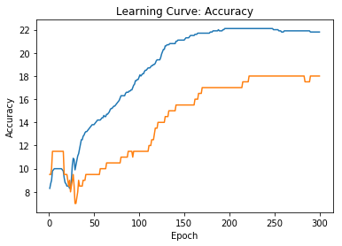

```
########### Learning Rate : 1.0   |   Iterations : 300   |   Hidden Neurons : 75 ###########
Training time: 62.63617968559265
```

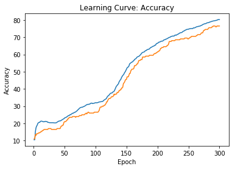

```
########### Learning Rate : 10.0  |   Iterations : 300   |   Hidden Neurons : 75 ###########
Training time: 57.67992925643921
```

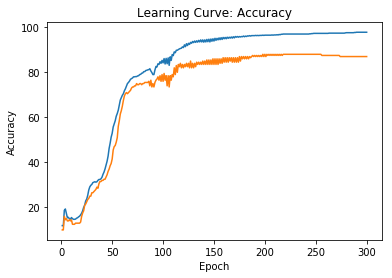

```
8604
```

```python
# Define your neural network

# 15 hidden neurons
mnist_model = NeuralNetwork(784,15,10)

# Learning rate 0.1
print('\n########### Learning Rate : 0.1   |   Iterations : 300   |   Hidden Neurons : 15 ###########')
mnist_model.train(small_training_data , small_validation_data , iterations=300, learning_rate=0.1, verbose=False)
mnist_model.predict(test_data)
mnist_model.weights_init(wi=None,wo=None)


# Learning rate 1.
print('\n########### Learning Rate : 1.0   |   Iterations : 300   |   Hidden Neurons : 15 ###########')
mnist_model.train(small_training_data , small_validation_data , iterations=300, learning_rate=1.0, verbose=False)
mnist_model.predict(test_data)
mnist_model.weights_init(wi=None,wo=None)

# Learning rate 10.
print('\n########### Learning Rate : 10.0  |   Iterations : 300   |   Hidden Neurons : 15 ###########')
mnist_model.train(small_training_data , small_validation_data , iterations=300, learning_rate=10.0, verbose=False)
mnist_model.predict(test_data)
mnist_model.weights_init(wi=None,wo=None)


# 75 hidden neurons
mnist_model = NeuralNetwork(784,75,10)

# Learning rate 0.1
print('\n########### Learning Rate : 0.1   |   Iterations : 300   |   Hidden Neurons : 75 ###########')
mnist_model.train(small_training_data , small_validation_data , iterations=300, learning_rate=0.1, verbose=False)
mnist_model.predict(test_data)
mnist_model.weights_init(wi=None,wo=None)


# Learning rate 1.
print('\n########### Learning Rate : 1.0   |   Iterations : 300   |   Hidden Neurons : 75 ###########')
mnist_model.train(small_training_data , small_validation_data , iterations=300, learning_rate=1.0, verbose=False)
mnist_model.predict(test_data)
mnist_model.weights_init(wi=None,wo=None)

# Learning rate 10.
print('\n########### Learning Rate : 10.0  |   Iterations : 300   |   Hidden Neurons : 75 ###########')
mnist_model.train(small_training_data , small_validation_data , iterations=300, learning_rate=10.0, verbose=False)
mnist_model.predict(test_data)
```

**Question 2.1.3**: Repeat Questions 2.1.2 and 2.1.3 on the very small datasets. You will use small_validation_data for validation.

```
########### Learning Rate : 0.1   |   Iterations : 300   |   Hidden Neurons : 30 ###########
Training time: 6.11288857460022
```

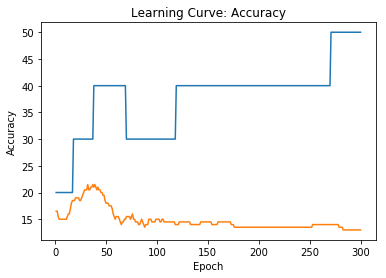

```
########### Learning Rate : 1.0   |   Iterations : 300   |   Hidden Neurons : 30 ###########
Training time: 5.6309874057769775
```

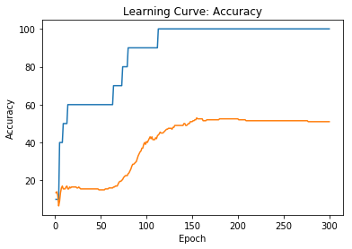

```
########### Learning Rate : 10.0   |   Iterations : 300   |   Hidden Neurons : 30 ###########
Training time: 6.171719312667847
```

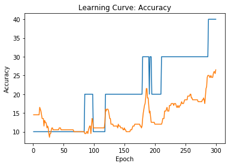

```
########### Learning Rate : 0.1   |   Iterations : 300   |   Hidden Neurons : 15 ###########
Training time: 6.064143180847168
```

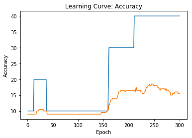

```
########### Learning Rate : 1.0   |   Iterations : 300   |   Hidden Neurons : 15 ###########
Training time: 5.533665418624878
```

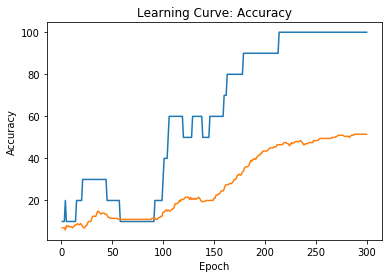

```
########### Learning Rate : 10.0  |   Iterations : 300   |   Hidden Neurons : 15 ###########
Training time: 4.387105941772461
```

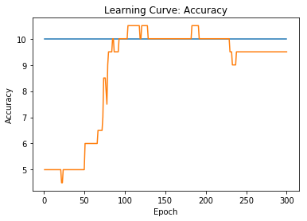

```
########### Learning Rate : 0.1   |   Iterations : 300   |   Hidden Neurons : 75 ###########
Training time: 6.840479373931885
```

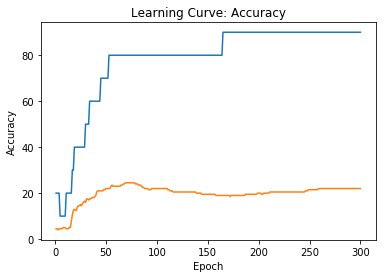

```
########### Learning Rate : 1.0   |   Iterations : 300   |   Hidden Neurons : 75 ###########
Training time: 6.950273752212524
```

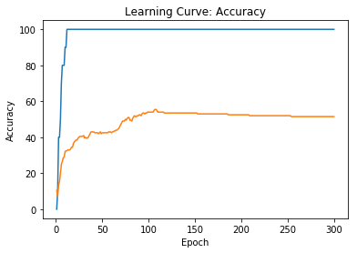

```
########### Learning Rate : 10.0  |   Iterations : 300   |   Hidden Neurons : 75 ###########
Training time: 7.032104015350342
```

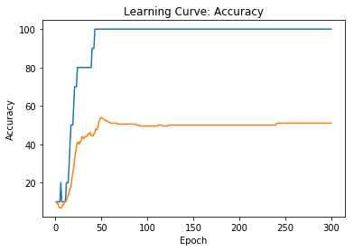

```
5083
```

```python
# Train NN and print accuracy on test data

# 30 hidden neurons
mnist_model = NeuralNetwork(784,30,10)

# Learning rate 0.1
print('\n########### Learning Rate : 0.1   |   Iterations : 300   |   Hidden Neurons : 30 ###########')
mnist_model.train(vsmall_training_data , small_validation_data , iterations=300, learning_rate=0.1, verbose=False)
mnist_model.predict(test_data)
""" predict() evaluates performance by counting how many examples in test_data are correctly evaluated. """
mnist_model.weights_init(wi=None,wo=None)


# Learning rate 1.
print('\n########### Learning Rate : 1.0   |   Iterations : 300   |   Hidden Neurons : 30 ###########')
mnist_model.train(vsmall_training_data , small_validation_data , iterations=300, learning_rate=1.0, verbose=False)
mnist_model.predict(test_data)
""" predict() evaluates performance by counting how many examples in test_data are correctly evaluated. """
mnist_model.weights_init(wi=None,wo=None)


# Learning rate 10.
print('\n########### Learning Rate : 10.0   |   Iterations : 300   |   Hidden Neurons : 30 ###########')
mnist_model.train(vsmall_training_data , small_validation_data , iterations=300, learning_rate=10.0, verbose=False)
mnist_model.predict(test_data)
""" predict() evaluates performance by counting how many examples in test_data are correctly evaluated. """
mnist_model.weights_init(wi=None,wo=None)


# 15 hidden neurons
mnist_model = NeuralNetwork(784,15,10)

# Learning rate 0.1
print('\n########### Learning Rate : 0.1   |   Iterations : 300   |   Hidden Neurons : 15 ###########')
mnist_model.train(vsmall_training_data , small_validation_data , iterations=300, learning_rate=0.1, verbose=False)
mnist_model.predict(test_data)
mnist_model.weights_init(wi=None,wo=None)


# Learning rate 1.
print('\n########### Learning Rate : 1.0   |   Iterations : 300   |   Hidden Neurons : 15 ###########')
mnist_model.train(vsmall_training_data , small_validation_data , iterations=300, learning_rate=1.0, verbose=False)
mnist_model.predict(test_data)
mnist_model.weights_init(wi=None,wo=None)

# Learning rate 10.
print('\n########### Learning Rate : 10.0  |   Iterations : 300   |   Hidden Neurons : 15 ###########')
mnist_model.train(vsmall_training_data , small_validation_data , iterations=300, learning_rate=10.0, verbose=False)
mnist_model.predict(test_data)
mnist_model.weights_init(wi=None,wo=None)


# 75 hidden neurons
mnist_model = NeuralNetwork(784,75,10)

# Learning rate 0.1
print('\n########### Learning Rate : 0.1   |   Iterations : 300   |   Hidden Neurons : 75 ###########')
mnist_model.train(vsmall_training_data , small_validation_data , iterations=300, learning_rate=0.1, verbose=False)
mnist_model.predict(test_data)
mnist_model.weights_init(wi=None,wo=None)


# Learning rate 1.
print('\n########### Learning Rate : 1.0   |   Iterations : 300   |   Hidden Neurons : 75 ###########')
mnist_model.train(vsmall_training_data , small_validation_data , iterations=300, learning_rate=1.0, verbose=False)
mnist_model.predict(test_data)
mnist_model.weights_init(wi=None,wo=None)

# Learning rate 10.
print('\n########### Learning Rate : 10.0  |   Iterations : 300   |   Hidden Neurons : 75 ###########')
mnist_model.train(vsmall_training_data , small_validation_data , iterations=300, learning_rate=10.0, verbose=False)
mnist_model.predict(test_data)
```

**Question 2.1.5**: Explain the results you obtained at Questions 2.1.2, 2.1.3 and 2.1.4.